# Лабораторная работа 1, вариант 17

1. Задать объем выборки $N$.

```r
  N = 1000
```

2. Задать параметры

```r
  p1 = 0.1
  p2 = 0.2

  mu = 0
  sigma_2 = 16

  d = 3

  a = 0
  b = 5

  pi_1 = 1/pi
```

3 Найти аналитически для своего варианта функцию распределения F моделируемого закона и плотность распределения. Вычислить математическое ожидание и дисперсию этого распределения.

3.1 Функция распределения смеси Нормального, Арксинуса и равномерного:

$F(x) = 0.1 *[1 + erf(\frac{x}{4\sqrt{2}})] + 0.2 * [0.5 + \frac{1}{\pi} * \arcsin(\frac{x}{3})] + 0.7 * [\frac{x}{5}]$

3.2 Плотность распределения смеси Нормального, Арксинуса и равномерного:

$f(x) = 0.1* [\frac{1}{4\sqrt{2\pi}}*e^{-\frac{x^2}{32}}] + 0.2*[\frac{1}{\pi}*\frac{1}{\sqrt{(9-x^2)}}] + 0.7 * [\frac{1}{5}]$

3.4 Дисперсия смеси:

$E_1[X^2] = D_1[x] + E_1^2[X] = \sigma^2 + \mu^2 = 16$,

$E_2[X^2] = D_2[x] + E_2^2[X] = \frac{1}{8} + \frac{1}{4} = 0.375$,

$E_3[X^2] = D_3[x] + E_3^2[X] = \frac{25}{12} + \frac{25}{4} = 8.333$

$0.1 * E_1[X^2] + 0.2 * E_2[X^2] + 0.7 * E_3[X^2] = E[X^2] = 0.1 * 16 + 0.2 * 0.375 + 0.7 * 8.333 = 7.5081$

$E_1^2[X] = 0$,

$E_2^2[X] = \frac{1}{4}$,

$E_3^2[X] = \frac{25}{4}$

$0.1 * E_1^2[X] + 0.2 * E_2^2[X] + 0.7 * E_3^2[X] = E^2[X] = 0 + 0.2 * \frac{1}{4} + 0.7 * \frac{25}{4} = 4.425$

4. Смоделировать с помощью генераторов случайных чисел выборку из заданного (согласно своему варианту) распределения.

```r
  F2 <- function(x) {
    return (1/2 + pi_1 * asin(x/d))
  }

  F2_inv <- function(y) {
    return (d*sin(pi/2 * (2*y - 1)))
  }
```

```r
  U1 = rnorm(N, mu, sigma_2) # norm distribution
  U  = runif(N, 0, 1)
  U2 = F2_inv(U)             # arcsin distribution, Smirnov method
  U3 = runif(N, a, b)        # uniform distribution
```

```r
  random_vector = runif(N, 0, 1)
  mixed = U1*(random_vector <= p1) + U2*(random_vector >= p1 & random_vector < p1 + p2) + U3*(random_vector > p1 + p2)
```

5. Построить в одном графическом окне графики функции распределения F и эмпирической функции распределения Fn, сравнить их визуально.

```r
  F <- function(x) {

    # distribution mix
      return ( p1 * pnorm(x, mean=mu, sd = sqrt(sigma_2)) + p2 * (0.5 + pi_1 * asin(x/d)) + (1 - p1 - p2) * punif(x, a, b))
  }
```

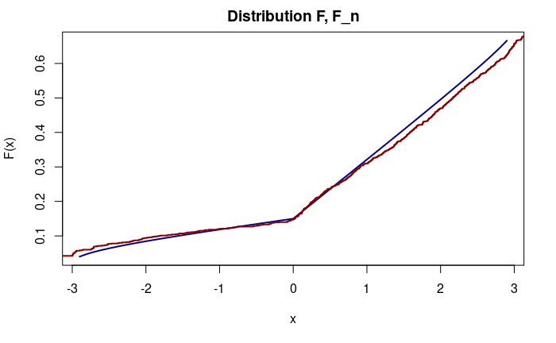

```r
  x = seq( -2.9, 2.9, 0.1)
  plot(x, F(x), main = "Distribution F, F_n", type="l", col="dark blue", lwd=2)
  lines(ecdf(mixed), col="dark red", lwd=2)
```

```r
NA
```

6. Построить в одном графическом окне график плотности распределения и гистограмму относительных частот, задав количество интервалов по формуле $m = round (1.72 · n^\frac{1}{3})$

```r
  f <- function(x) {

    # density mix
    return ( p1 * dnorm(x, mean=mu, sd = sqrt(sigma_2)) + p2 * (pi_1 * 1/sqrt(d^2 - x^2)) + (1 - p1 - p2) * dunif(x, a, b) )
  }
```

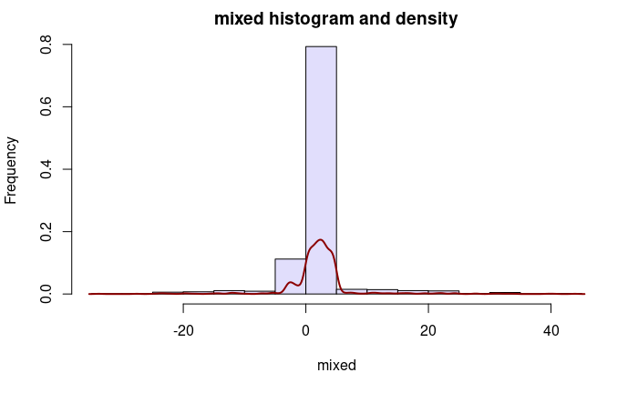

```r
  h = hist(mixed, breaks = round(1.72*(N ** (1/3))), plot=FALSE)
  h$counts=h$counts/sum(h$counts)
  plot(h,  main = "mixed histogram and density", col = "#E1DEFC")
  lines(density(mixed), type="l", col="dark red", lwd=2)
```

```r
NA
```

7. Вычислить значения оценок математического ожидания и дисперсии по полученной в п. 4 выборке. Сравнить статистические оценки математического ожидания и дисперсии с их теоретическими значениями.

```r
  mean_mixed = mean(mixed)
  var_mixed = var(mixed)
  cat("Mean = 1.85", "\nMean_mixed = ", mean_mixed, "\nError mean = ", abs(mean_mixed -  1.85))
```

```
Mean = 1.85
Mean_mixed =  2.230117
Error mean =  0.3801169
```

```r
  cat("\nVar  = 3.0831", "\nVar_mixed = ", var_mixed, "\nError var  = ", abs(var_mixed  -  3.0831))
```

```
Var  = 3.0831
Var_mixed =  34.76036
Error var  =  31.67726
```

8. Построить асимптотические доверительные интервалы для «неизвестных» математического ожидания и дисперсии с доверительными вероятностями 0.9, 0.95 и по правилу 3σ (т.е. с доверительной вероятностью 0.9974). Убедиться в том, что теоретические математическое ожидание и дисперсия содержатся в этих интервалах.

```r
  sqrt_N_inv = 1/sqrt(N)

  for (alpha in c(0.1, 0.05, 0.0026)) {

      q = qnorm(1 - alpha/2)
      S = sd(mixed)
      mean_interval = c(mean_mixed - q * S * sqrt_N_inv, mean_mixed + q * S * sqrt_N_inv)

      M_2 = sum((mixed - mean_mixed) ** 2) / N
      M_4 = sum((mixed - mean_mixed) ** 4) / N

      sqrt_moments = (M_4 - M_2 ** 2) ** (0.5)
      var_interval = c(var_mixed - q * sqrt_moments * sqrt_N_inv, var_mixed + q * sqrt_moments * sqrt_N_inv)


      cat(mean_interval, " - доверительный интервал для м.о с уровнем значимости ", alpha, "\n")
      cat(var_interval, " - доверительный интервал для дисперсии с уровнем значимости ", alpha, "\n\n")
  }
```

```
1.923448 2.536786  - доверительный интервал для м.о с уровнем значимости  0.1
27.35437 42.16635  - доверительный интервал для дисперсии с уровнем значимости  0.1

1.864699 2.595535  - доверительный интервал для м.о с уровнем значимости  0.05
25.93558 43.58514  - доверительный интервал для дисперсии с уровнем значимости  0.05

1.668658 2.791576  - доверительный интервал для м.о с уровнем значимости  0.0026
21.20122 48.3195  - доверительный интервал для дисперсии с уровнем значимости  0.0026
```

9. Найти статистические оценки $B_N$ и $E_N$ параметров асимметрии $β = μ3/σ3$ и эксцесса $ε = μ4/σ4 − 3$. Являются ли эти оценки состоятельными? несмещенными?

```r
  M_3 = sum((mixed - mean_mixed) ** 3) / N

  B = M_3/((var_mixed) ** (3/2))
  E = M_4/(var_mixed ** 2)


  cat("Параметр асимметрии B = ", B, "\n")
```

```
Параметр асимметрии B =  0.9983152
```

```r
  cat("Параметр эксцесса   E = ", E)
```

```
Параметр эксцесса   E =  17.77613
```

10. Найти для своего распределения теоретические медиану и квантили уровней $0.25$ и $0.75$. Найти по выборке их статистические оценки, т.е. выборочную медиану и выборочные квантили тех же уровней. Сравнить оценки с соответствующими теоретическими значениями. Посмотреть, что будет происходить с увеличением объема выборки $N$.

Теоретическая медиана $F(X) = 0.5 $

```r
  mediana_mixed = median(mixed)

  quantiles_mixed = quantile(mixed, probs = c(0.25, 0.75),  na.rm = TRUE, names = FALSE)
  cat("Медиана mixed  = ", mediana_mixed, "\n")
```

```
Медиана mixed  =  2.168071
```

```r
  cat("Квантили mixed = ", quantiles_mixed, "\n")
```

```
Квантили mixed =  0.6184019 3.712168
```

```r
    # solve F(x) = 0.5

    F_slied <- function(x) ( F(x) - 0.5)
    mediana_theoretical <- uniroot(F_slied, c(0, 3), tol = 0.01)
    cat("Медиана theoretical  = ", mediana_theoretical$root, "\n")
```

```
Медиана theoretical  =  2.024695
```

```r
    cat("Ошибка медианы       = ", abs(mediana_mixed - mediana_theoretical$root))
```

```
Ошибка медианы       =  0.1433765
```

```r
  quantile_theoretical = quantile(F(x), probs = c(0.25, 0.75), na.rm = TRUE, names = FALSE)

  cat("Квантили theoretical = ", quantile_theoretical, "\n")
```

```
Квантили theoretical =  0.1037288 0.3992712
```

```r
  cat("Ошибка квантили      = ", abs(quantiles_mixed - quantile_theoretical))
```

```
Ошибка квантили      =  0.5146731 3.312897
```

Лабораторная работа 3 (2)

```r
  dN = N**(-1/5)
  sMixed = sort(mixed)
  grid = seq(0, sMixed[N] + 1, 0.001)

  p_N <- c(1:N) * 0

  for (i in 1:N) {
    p_N[i] = 1/(N*dN) * sum(Kernel5((sMixed - grid[i])/dN))
  }
```

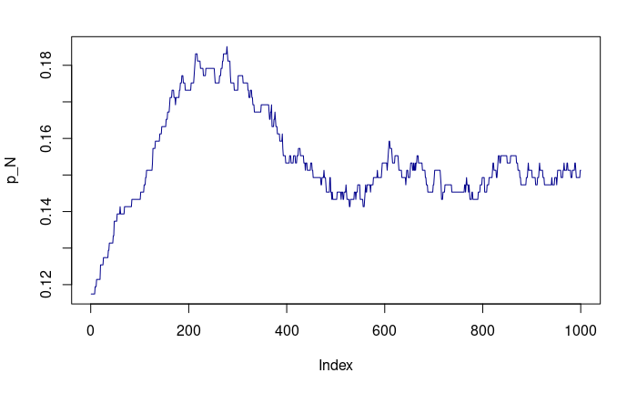

```r
  plot(p_N, col = "dark blue", type = "l")
```

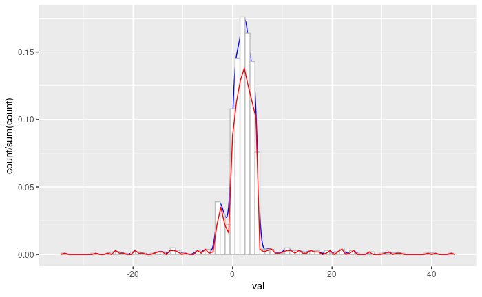

```r
  library(ggplot2)

  df <- data.frame(val = mixed)

  ggplot(df, aes(val)) +
    geom_density(color = "blue")  +
    geom_histogram(binwidth = 1, color="gray", fill="white", aes(y =..count../sum(..count..))) +
    geom_freqpoly(bins=100, color="red", aes(y =..count../sum(..count..)))
```